# Workshop 1

Dan Aukes

10-18-2024

# Welcome

## Agenda

- Learning good design with MuJoCo

## Not an Expert

- Use reinforcement learning on custom problems
- What are all the parts and pieces?

## What are we going to learn today?

- Reinforcement learning
- MuJoCo
- Gymnasium
- Tensorboard

## Installing

```bash
sudo add-apt-repository ppa:deadsnakes/ppa -y
sudo apt update
sudo apt install python3.11-venv
python3.11 -m venv ~/envs/sb3
. envs/sb3/bin/activate
pip install --upgrade pip
pip install mujoco==2.3.7
pip install gymnasium[mujoco]
pip install 'stable-baselines3[extra]'
pip install jupyter
pip install mediapy
```

## Conda approach

```bash
conda create -y -n sb3 python=3.11
conda activate sb3
conda install pip
pip install mujoco==2.3.7
pip install gymnasium[mujoco]
pip install stable-baselines3[extra]
conda install -y jupyter
conda install -y -c conda-forge libstdcxx-ng # see note
conda env config vars set MUJOCO_GL=osmesa PYOPENGL_PLATFORM=osmesa
conda deactivate && conda activate sb3
```

fix for anaconda linux, found here: https://stackoverflow.com/questions/71010343/cannot-load-swrast-and-iris-drivers-in-fedora-35/72200748#72200748

## A Note on OS’s

- Mac and Linux ship with Python installed
- Has become central to many operations in these OS’s
- You can mess up these installs by installing your own software
- They now prevent you from using pre-installed version, need your own install / environment ny alternatives

## Environments

- Alternative to docker
- Different directories for different Python Versions
- Management Tools:
  - pip / venv
  - conda
  - poetry
  - uv
  - rye
  - pyenv
  - virtualenv

https://alpopkes.com/posts/python/packaging_tools/

## Windows

- Install python 3.11
- If you add to path, make sure you are calling python 3.11
- Environment not explicitly necessary
- Conda can help in this case
- Not tested.

## Jupyter Lab

```bash
. envs/sb3/bin/activate
```

```bash
jupyter lab
```

## Stable Baselines 3

- Based on Pytorch
- Pre-tuned, well documented algorithms
- Good documentation
- An easy way to
  - connect environments to algorithms
  - run learning
  - save
  - log
- https://stable-baselines3.readthedocs.io/
- https://github.com/DLR-RM/stable-baselines3?tab=readme-ov-file
- https://araffin.github.io/post/sb3/

## Gym / Gymnasium

- Implementation-agnostic interface for learning in different environments
- Typically physics-based
- Basic functions: (init, reset, step, render)

## Gym Interfaces

- Classic-control: Acrobot, CartPole, Mountain Car, Continuous Mountain Car
- Atari-sim
- Box2D
- Pybullet
- **[MuJoCo](https://gymnasium.farama.org/environments/mujoco/)**
- [others](https://gymnasium.farama.org/environments/third_party_environments/)
- https://pypi.org/project/gymnasium/
- https://gymnasium.farama.org/environments/mujoco/half_cheetah/
- https://github.com/Farama-Foundation/Gymnasium/
- https://github.com/Farama-Foundation/gym-examples

## Examples and links

- https://pypi.org/project/gymnasium/
- https://gymnasium.farama.org/environments/mujoco/half_cheetah/
- https://github.com/Farama-Foundation/Gymnasium/
- https://github.com/Farama-Foundation/gym-examples

## Tensorboard

View and display progress

[figure not shown]

## Other viewers

- Weights and Biases

## Physics with MuJoCo

- Covered more in-depth in my Foldable Robotics Course
- Rigid Body Simulation featuring
  - Bodies
  - Cameras
  - Lights
  - Sensors
  - Motors

## Why do I like it?

- Well-documented
- can be CPU-based (accessible but drawbacks)
- Flexible friction formulation
- Different integrators
- Access to contact information
- …

## Other Options

- Isaac Sim: https://github.com/isaac-sim
- Isaac Gym: https://developer.nvidia.com/blog/introducing-isaac-gym-rl-for-robotics/
- Feature Comparison: https://github.com/google-deepmind/mujoco/issues/1161

## Note on versioning

- Mujoco 2 vs. 2.1
- Mujoco 2 vs. 3
- Gym vs. Gymnasium
- Documentation is confusing and old

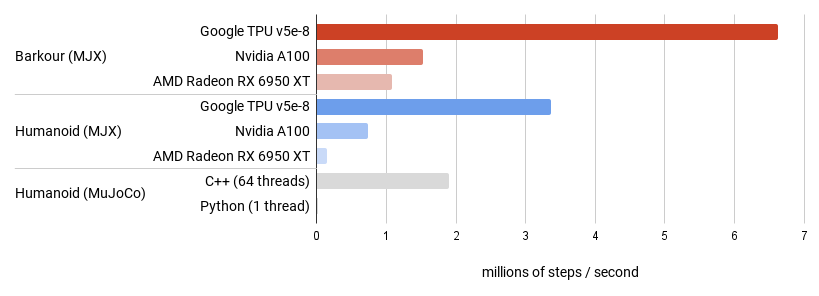

- https://github.com/openai/mujoco-py
- https://github.com/openai/gym
- https://gymnasium.farama.org/environments/mujoco/

# Implementation

## What do I want

- Create new environment
- Build learning pipeline
- Learn
- Watch my progress
- View Results

## Existing MuJoCo Environments

https://github.com/Farama-Foundation/Gymnasium/tree/main/gymnasium/envs/mujoco

## Build MuJoCo Simulation

- Python Implementation
- XML file walkthrough
- Templating
- Test code
- Controller

https://mujoco.readthedocs.io/en/stable/XMLreference.html

## File Structure

```
.
├── my_envs
│   ├── biped.py
│   ├── biped.xml
│   ├── __init__.py
├── log
│   └── 2024-10-17-23-06
│       ├── first_run_1
│       │   └── ...
│       └── ...
├── biped.ipynb
├── learn.ipynb
└── play.ipynb
```

Suggested file structure: https://gymnasium.farama.org/tutorials/gymnasium_basics/environment_creation/#generate-your-environment

## Make your own Environment

- Inherit `gym.Env` class
- Reimplement: `__init__()`, `reset()`, `step()`, `render()`, `close()` classes
- Register to “vectorize”
- https://gymnasium.farama.org/introduction/create_custom_env/
- https://gymnasium.farama.org/tutorials/gymnasium_basics/environment_creation/
- https://gymnasium.farama.org/environments/mujoco/

## `__init()__` Details

- Scale your
  - action space
  - observation space

## “Reward Shaping”

- Reward should combine:
  - everything you want:
  - *not* everything you don’t want
- Scaling these preferences is a “dark art”.
  - No right answer
  - Takes trial and error
  - From a non-expert, this is the reason for so much critique of RL.

## Steps, Runs, and Time

- Num Steps per episode
- Steps per sim/step
- Total steps

## Termination and Truncation

- termination: when the simulation is finished due to success *or* failure
  - example: robot reaches goal or falls down
- truncation: arbitrarily stop the program
- finite-horizon vs infinite horizon discussion

https://gymnasium.farama.org/tutorials/gymnasium_basics/handling_time_limits/

## Rendering

- plan for different modes

## Stochasticity

- Good learning algorithms need to learn on various conditions
  - starting conditions
  - design variations
  - envrionment variation
- Use a random seed
- Switch deterministic or not

## Registering

look at `__init__.py`

- Namespace, file, object
- Options:
  - reward_threshold
  - nondeterministic
  - max_episode_steps
  - order_enforce
  - kwargs

# Stable Baselines 3

## Import

```python
import gymnasium as gym
import my_envs
from stable_baselines3 import PPO
import numpy
import matplotlib.pyplot as plt
```

## Setup

```python
now = datetime.datetime.now()
run_prefix = datetime.datetime.strftime(now, '%Y-%m-%d-%H-%M')
```

## Run and Save

```python
env = gym.make("biped",render_mode='none')
model = PPO("MlpPolicy", env, verbose=1,
            ensorboard_log='log/'+run_prefix+'/')
model.learn(total_timesteps=10000,
            tb_log_name="first_run")
model.save(run_prefix+'-1.zip')
env.close()
```

## While you’re running

```bash
tensorboard --logdir log
```

## Continue Running

```python
env = gym.make("biped",render_mode='none')
model = PPO.load(run_prefix+'-1.zip', env=env)
model.learn(total_timesteps=200000,
            tb_log_name="second_run",
            reset_num_timesteps=False)
model.save(run_prefix+'-2.zip')
env.close()
```

## Play Back

```python
env = gym.make("biped",render_mode='human')
model = PPO.load("2024-10-17-23-06-3",env=env)

vec_env = model.get_env()
vec_env.render_mode='human'
obs = vec_env.reset()
actions = []
rewards = []
states = []
for i in range(200):
    action, _states = model.predict(obs, deterministic=True)
    actions.append(action)
    obs, reward, done, info = vec_env.step(action)
    vec_env.render("human")
    states.append(obs)
```

## Higher Levels of Abstraction

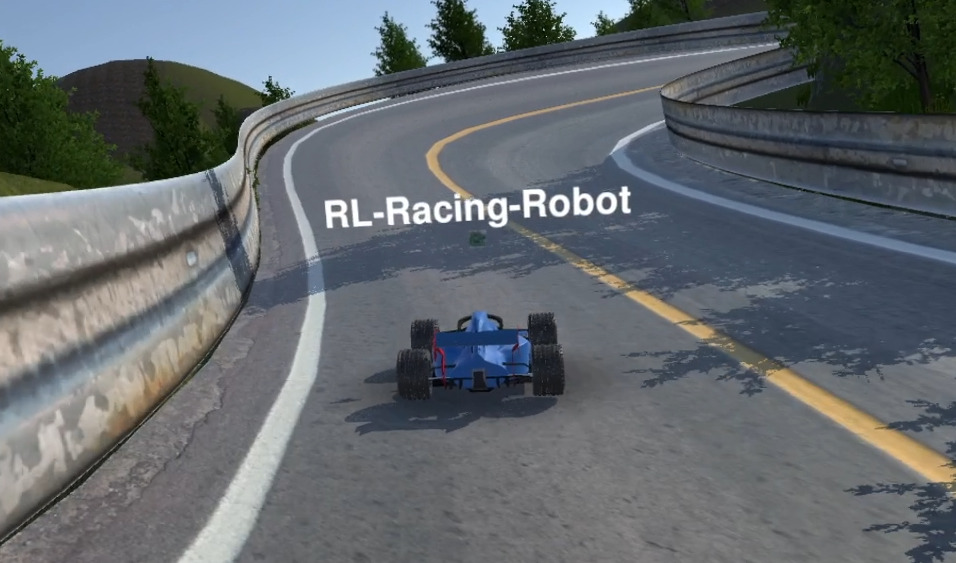

Zoo: https://github.com/DLR-RM/rl-baselines3-zoo

## Other useful links and tutorials

- https://araffin.github.io/post/sb3/
- https://github.com/araffin/rl-tutorial-jnrr19?tab=readme-ov-file
- https://github.com/Stable-Baselines-Team/rl-colab-notebooks/tree/sb3

## Upcoming

- Git / Github
- Micropython, ESP32, Sensors, Etc.
- Object Oriented Python
- Sensor Fusion

## Email List

[figure not shown]